## Consideraciones entregadas por el negocio:

### 1. Es 5 veces peor clasificar un cliente como bueno cuando es malo, que malo cuando es bueno

### 2. Las tarifas telefónicas son altas en el pais de donde provienen los clientes de este banco

### 3. Hay una alta tasa de migración en el pais de donde provienen los clientes de este banco

```r
library(tidyverse)
```

```r
library(rpart)
library(rpart.plot)
library(caret)
library(ggplot2)
library(pROC)
library(ROCR)
```

## Cargar data

### Se cambian nombres de columnas para mayor comodidad y se cambia la clasificación por 0: “bueno”, 1: “malo”

```r
data_raw <- read.table("data_desafio_seguros", header = TRUE, sep = ",")
column_names <- c('id_row','estado_cta_corriente','duracion_meses','historia_cred','prop_cred','monto_cred','ahorros_cuenta','tiempo_empleo_actual'
                  ,'tasa_plazo_renta_disp','estatus_sexo','otros_deud_garan','tiempo_residencia','posesiones','edad','otros_pagos_pend'
                  ,'forma_vive','n_creditos_existentes','tipo_trabajo','n_personas_responsable','tiene_telefono','extranjero','clasificacion')
colnames(data_raw) <- column_names
data_raw$clasificacion <- ifelse(data_raw$clasificacion == 1, 0, 1)

# data_aux <- data_raw %>% mutate(tiene_cta_corriente = ifelse(estado_cta_corriente %in% c('A14'), 0, 1)
#                                 ,cuenta_critica = ifelse(historia_cred %in% c('A34'), 1, 0)
#                                 ,ahorros_en_cta = ifelse(ahorros_cuenta %in% c('A65'), 0, 1)
#                                 ,emp_mayor_al_año = ifelse(tiempo_empleo_actual %in% c('A71','A72'), 0, 1)
#                                 ,tiene_pagos_pendientes = ifelse(otros_pagos_pend %in% c('A143'), 0, 1)
#                                 ,credito_por_bien = ifelse(prop_cred %in% c('A40','A41','A42','A43','A44'), 1, 0)
#                                 ,tiene_fono = ifelse(tiene_telefono == 'A192', 1, 0)
#                                 )

# data <- data_aux %>% select(tiene_cta_corriente, cuenta_critica, ahorros_en_cta, emp_mayor_al_año, tiene_pagos_pendientes, credito_por_bien
#                             , tiene_fono, duracion_meses, monto_cred, tasa_plazo_renta_disp, tiempo_residencia, edad, n_creditos_existentes
#                             , n_personas_responsable, clasificacion
#                             )

# data_raw$clasificacion <- as.factor(data_raw$clasificacion)
# data <- data_raw %>% mutate_if(is.numeric, funs(as.numeric(scale(.))))
data <- data_raw
```

### Resumen de dataset

```r
summary(data)
```

```
##      id_row      estado_cta_corriente duracion_meses  historia_cred
##  Min.   :  0.0   A11:243              Min.   : 4.00   A30: 32
##  1st Qu.:253.8   A12:242              1st Qu.:12.00   A31: 46
##  Median :504.5   A13: 61              Median :18.00   A32:472
##  Mean   :501.7   A14:354              Mean   :21.09   A33: 84
##  3rd Qu.:750.5                        3rd Qu.:24.00   A34:266
##  Max.   :999.0                        Max.   :72.00
##
##    prop_cred     monto_cred    ahorros_cuenta tiempo_empleo_actual
##  A43    :246   Min.   :  250   A61:538        A71: 57
##  A40    :214   1st Qu.: 1382   A62: 94        A72:151
##  A42    :169   Median : 2328   A63: 60        A73:309
##  A41    : 93   Mean   : 3276   A64: 43        A74:155
##  A49    : 87   3rd Qu.: 3994   A65:165        A75:228
##  A46    : 45   Max.   :18424
##  (Other): 46
##  tasa_plazo_renta_disp estatus_sexo otros_deud_garan tiempo_residencia
##  Min.   :1.000         A91: 47      A101:820         Min.   :1.00
##  1st Qu.:2.000         A92:273      A102: 37         1st Qu.:2.00
##  Median :3.000         A93:494      A103: 43         Median :3.00
##  Mean   :2.976         A94: 86                       Mean   :2.85
##  3rd Qu.:4.000                                       3rd Qu.:4.00
##  Max.   :4.000                                       Max.   :4.00
##
##  posesiones      edad       otros_pagos_pend forma_vive
##  A121:251   Min.   :19.00   A141:128         A151:162
##  A122:214   1st Qu.:27.00   A142: 42         A152:640
##  A123:298   Median :33.00   A143:730         A153: 98
##  A124:137   Mean   :35.57
##             3rd Qu.:42.00
##             Max.   :75.00
##
##  n_creditos_existentes tipo_trabajo n_personas_responsable tiene_telefono
##  Min.   :1.000         A171: 19     Min.   :1.000          A191:531
##  1st Qu.:1.000         A172:180     1st Qu.:1.000          A192:369
##  Median :1.000         A173:569     Median :1.000
##  Mean   :1.398         A174:132     Mean   :1.148
##  3rd Qu.:2.000                      3rd Qu.:1.000
##  Max.   :4.000                      Max.   :2.000
##
##  extranjero clasificacion
##  A201:865   Min.   :0.0000
##  A202: 35   1st Qu.:0.0000
##             Median :0.0000
##             Mean   :0.2978
##             3rd Qu.:1.0000
##             Max.   :1.0000
##
```

## Dividiendo el dataset en train y test set

### Se ocupa un 70% del dataset para entrenar y un 30% para validar.

```r
set.seed(2)
sample_size <- floor(0.7*nrow(data))
train_ind <- sample(seq_len(nrow(data)), size = sample_size, replace = F)
train <- data[train_ind, ]
test <- data[-train_ind, ]
```

## Modelo

### El modelo elegido es de regresión lógistica debido a la naturaleza del output que estamos buscando (probabilidad de ser un cliente “malo”, entre 0 - 1). Usamos train[-1] para no tomar en cuenta la variable id_row

```r
glm_model <- glm(formula = clasificacion ~., data = train[-1], family = binomial(link = 'logit'))
summary(glm_model)
```

```
##
## Call:
## glm(formula = clasificacion ~ ., family = binomial(link = "logit"),
##     data = train[-1])
##
## Deviance Residuals:
##     Min       1Q   Median       3Q      Max
## -2.5201  -0.6791  -0.3505   0.5975   2.6500
##
## Coefficients:
##                           Estimate Std. Error z value Pr(>|z|)
## (Intercept)             -5.935e-02  1.422e+00  -0.042 0.966702
## estado_cta_corrienteA12 -4.673e-01  2.820e-01  -1.657 0.097496 .
## estado_cta_corrienteA13 -7.593e-01  4.596e-01  -1.652 0.098503 .
## estado_cta_corrienteA14 -1.861e+00  3.047e-01  -6.109 1.01e-09 ***
## duracion_meses           3.258e-02  1.226e-02   2.658 0.007866 **
## historia_credA31        -1.756e-01  7.346e-01  -0.239 0.811022
## historia_credA32        -7.094e-01  5.922e-01  -1.198 0.230972
## historia_credA33        -1.503e+00  6.479e-01  -2.319 0.020384 *
## historia_credA34        -1.614e+00  5.876e-01  -2.746 0.006028 **
## prop_credA41            -1.636e+00  4.876e-01  -3.356 0.000792 ***
## prop_credA410           -2.439e+00  1.097e+00  -2.222 0.026263 *
## prop_credA42            -7.410e-01  3.270e-01  -2.266 0.023457 *
## prop_credA43            -1.132e+00  3.231e-01  -3.505 0.000457 ***
## prop_credA44            -1.169e+00  1.009e+00  -1.158 0.246662
## prop_credA45            -3.187e-01  9.227e-01  -0.345 0.729747
## prop_credA46             8.048e-02  5.112e-01   0.157 0.874905
## prop_credA48            -1.469e+01  5.514e+02  -0.027 0.978743
## prop_credA49            -8.367e-01  4.566e-01  -1.832 0.066917 .
## monto_cred               1.189e-04  6.027e-05   1.973 0.048527 *
## ahorros_cuentaA62       -8.105e-01  3.830e-01  -2.116 0.034319 *
## ahorros_cuentaA63       -5.925e-02  4.673e-01  -0.127 0.899098
## ahorros_cuentaA64       -1.886e+00  7.549e-01  -2.499 0.012463 *
## ahorros_cuentaA65       -7.696e-01  3.361e-01  -2.290 0.022014 *
## tiempo_empleo_actualA72 -8.473e-01  5.454e-01  -1.554 0.120297
## tiempo_empleo_actualA73 -9.040e-01  5.335e-01  -1.695 0.090163 .
## tiempo_empleo_actualA74 -1.486e+00  5.818e-01  -2.555 0.010622 *
## tiempo_empleo_actualA75 -1.088e+00  5.359e-01  -2.030 0.042328 *
## tasa_plazo_renta_disp    4.914e-01  1.156e-01   4.250 2.14e-05 ***
## estatus_sexoA92         -3.606e-01  5.264e-01  -0.685 0.493368
```

[output cut: 15 more lines]

```
## tipo_trabajoA173         1.111e+00  8.383e-01   1.325 0.185022
## tipo_trabajoA174         9.401e-01  8.387e-01   1.121 0.262328
## n_personas_responsable   1.733e-01  3.449e-01   0.503 0.615259
## tiene_telefonoA192      -2.277e-01  2.598e-01  -0.876 0.380870
## extranjeroA202          -1.412e+00  7.549e-01  -1.871 0.061381 .
## ---
## Signif. codes:  0 '***' 0.001 '**' 0.01 '*' 0.05 '.' 0.1 ' ' 1
##
## (Dispersion parameter for binomial family taken to be 1)
##
##     Null deviance: 759.25  on 629  degrees of freedom
## Residual deviance: 543.51  on 581  degrees of freedom
## AIC: 641.51
##
## Number of Fisher Scoring iterations: 14
```

### Distribución de probabilidad en el set de validación

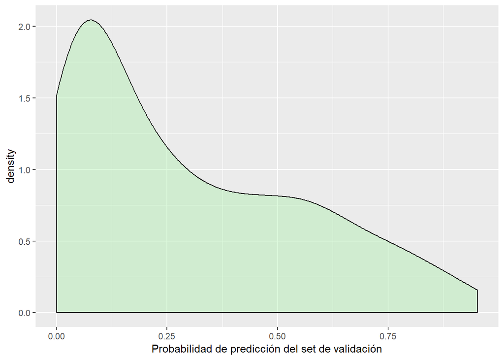

```r
preds = predict(glm_model , newdata = test[-1] , type = 'response')

ggplot(data.frame(preds) , aes(preds)) +
        geom_density(fill = 'lightgreen' , alpha = 0.3) +
        labs(x = 'Probabilidad de predicción del set de validación')
```

## Métricas

### Se calculan métricas (precision y recall) para distintos thresholds, con la finalidad de elegir un valor que maximice el recall. Esto con el fin de cumplir la regla de negocio “Es 5 veces peor clasificar un cliente como bueno cuando es malo, que malo cuando es bueno”"

```r
k = 0
accuracy = c()
precision = c()
recall = c()
for(i in seq(from = 0.1 , to = 0.5 , by = 0.01)){
        k = k + 1
        preds_binomial = ifelse(preds > i , 1 , 0)
        confmat = table(test$clasificacion , preds_binomial)
        accuracy[k] = sum(diag(confmat)) / sum(confmat)
        precision[k] = confmat[2 , 2] / sum(confmat[ , 2])
        recall[k] = confmat[2 , 2] / sum(confmat[2 , ])
}
```

### Se genera dataframe para posterior visualización

```r
threshold = seq(from = 0.1 , to = 0.5 , by = 0.01)

data_thresh = data.frame(threshold , accuracy , precision , recall)
head(data_thresh,10)
```

```
##    threshold  accuracy precision    recall
## 1       0.10 0.5888889 0.4285714 0.9176471
## 2       0.11 0.6037037 0.4382022 0.9176471
## 3       0.12 0.6074074 0.4400000 0.9058824
## 4       0.13 0.6111111 0.4418605 0.8941176
## 5       0.14 0.6148148 0.4424242 0.8588235
## 6       0.15 0.6296296 0.4534161 0.8588235
## 7       0.16 0.6592593 0.4771242 0.8588235
## 8       0.17 0.6592593 0.4765101 0.8352941
## 9       0.18 0.6629630 0.4797297 0.8352941
## 10      0.19 0.6740741 0.4895105 0.8235294
```

## Trade-off entre precision y recall

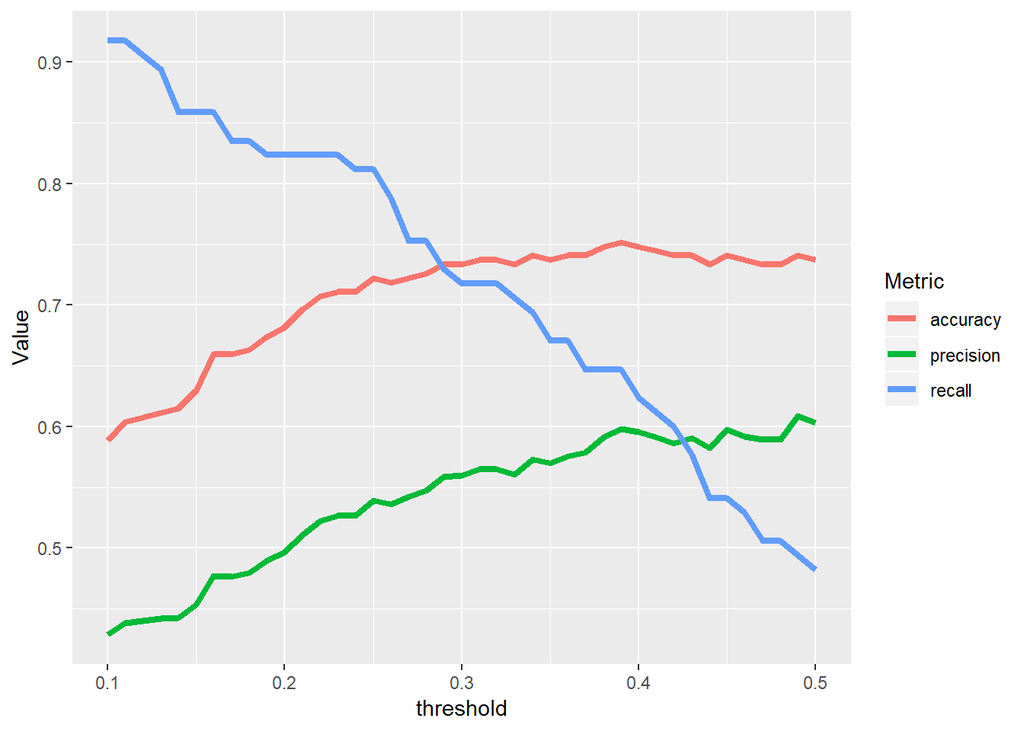

```r
ggplot(gather(data_thresh , key = 'Metric' , value = 'Value' , 2:4) ,
       aes(x = threshold , y = Value , color = Metric)) +
        geom_line(size = 1.5)
```

### Se elige 0.2 como el threshold óptimo para cumplir con las definiciones del negocio.

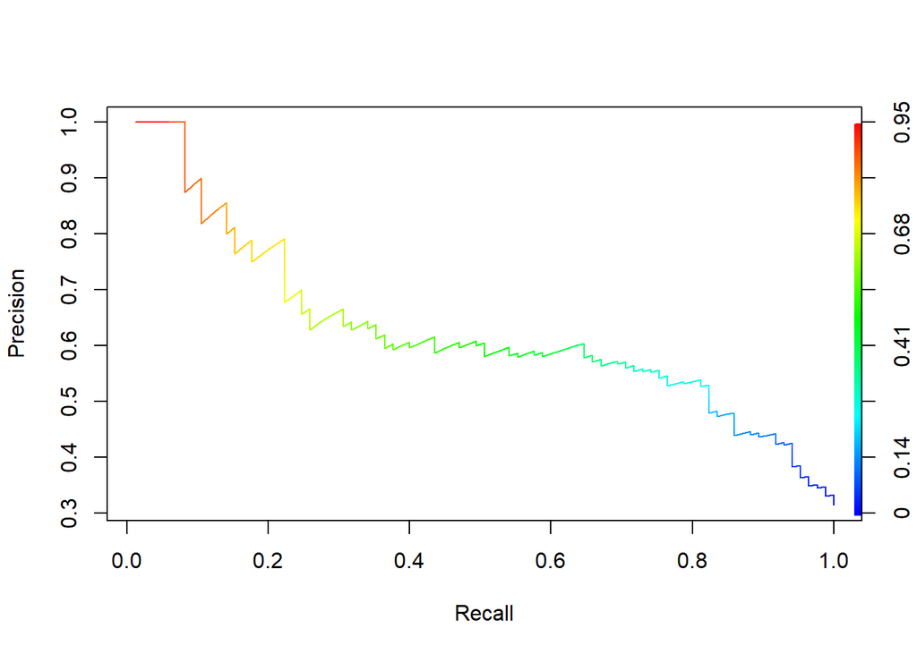

```r
# plot.roc(test$clasificacion , preds , main = "Intervalo de confianza del threshold" , percent = TRUE ,
#          ci = TRUE , of = "thresholds" , thresholds = "best" , print.thres = "best" , col = 'blue')

ROCRpred <- prediction(preds, test$clasificacion)
ROCRperf <- performance(ROCRpred, 'prec', 'rec')
plot(ROCRperf, colorize = TRUE, text.adj = c(-0.2, 1.7))
```

## Matriz de confusión

### Precision ~ 50% y recall ~ 82,5%

```r
final_threshold <- 0.2

preds_for_best = ifelse(preds > final_threshold , 1 , 0)
confusion_matrix_best = table(Real = test$clasificacion, Prediccion = preds_for_best)
confusion_matrix_best
```

```
##     Prediccion
## Real   0   1
##    0 114  71
##    1  15  70
```

## Cargando data de validación

```r
data_validacion <- read.csv("data_validacion_sin_clasificacion_banco.csv", header = TRUE, sep = ",")
column_names_val <- c('id_row','estado_cta_corriente','duracion_meses','historia_cred','prop_cred','monto_cred','ahorros_cuenta','tiempo_empleo_actual'
                  ,'tasa_plazo_renta_disp','estatus_sexo','otros_deud_garan','tiempo_residencia','posesiones','edad','otros_pagos_pend'
                  ,'forma_vive','n_creditos_existentes','tipo_trabajo','n_personas_responsable','tiene_telefono','extranjero')
colnames(data_validacion) <- column_names_val
```

## Generando predicción y escribiendo csv final

```r
pred_val <- predict(glm_model , newdata = data_validacion[-1] , type = 'response')
pred_val_clasificacion <- ifelse(pred_val > final_threshold, 2, 1)

entregable <- as.data.frame(cbind(data_validacion$id_row, pred_val_clasificacion))
colnames(entregable) <- c('row_id', 'predicciones')

write.csv(entregable, file = 'entregable_jsaavedra.csv', row.names = FALSE)
```